# Analiza Danych EDA Titanica: Eksploracja Domenowa

Data wykonania projektu: luty/marzec 2025

Analiza danych osób, które przeżyły bądź nie przeżyły katastrofy statku Titanic dnia 12.04.1912 roku. Jest to czysta analiza danych wywnioskowana z tabeli ofiar tragedii. Na różnych wykres i tablicach można ocenić różne aspekty przetrwania, np. kto i z jakiej klasy pasażerskiej miał większą szansę przeżyć tragedię. Zachęcam do zapoznania się z treścią notebooka, który można sobie pobrać poniżej.

Pobierz Notebook Pobierz Plik Bazy Danych

# Analiza TITANIC

## Import bibliotek

```python
import pandas as pd
import matplotlib.pyplot as plt
import seaborn as sns
```

## Import pliku z bazą danych i pokazanie 10 losowych wierszy

```python
df = pd.read_csv('26__titanic.csv', sep=',')

df.sample(10)
```

|  | pclass | survived | name | sex | age | sibsp | parch | ticket | fare | cabin | embarked | boat | body | home.dest |
| --- | --- | --- | --- | --- | --- | --- | --- | --- | --- | --- | --- | --- | --- | --- |
| 480 | 2.0 | 0.0 | Laroche, Mr. Joseph Philippe Lemercier | male | 25.0 | 1.0 | 2.0 | SC/Paris 2123 | 41.5792 | NaN | C | NaN | NaN | Paris / Haiti |
| 943 | 3.0 | 0.0 | Laitinen, Miss. Kristina Sofia | female | 37.0 | 0.0 | 0.0 | 4135 | 9.5875 | NaN | S | NaN | NaN | NaN |
| 543 | 2.0 | 0.0 | Reeves, Mr. David | male | 36.0 | 0.0 | 0.0 | C.A. 17248 | 10.5000 | NaN | S | NaN | NaN | Brighton, Sussex |
| 189 | 1.0 | 0.0 | Long, Mr. Milton Clyde | male | 29.0 | 0.0 | 0.0 | 113501 | 30.0000 | D6 | S | NaN | 126.0 | Springfield, MA |
| 44 | 1.0 | 1.0 | Burns, Miss. Elizabeth Margaret | female | 41.0 | 0.0 | 0.0 | 16966 | 134.5000 | E40 | C | 3 | NaN | NaN |
| 610 | 3.0 | 0.0 | Ahlin, Mrs. Johan (Johanna Persdotter Larsson) | female | 40.0 | 1.0 | 0.0 | 7546 | 9.4750 | NaN | S | NaN | NaN | Sweden Akeley, MN |
| 526 | 2.0 | 1.0 | Pallas y Castello, Mr. Emilio | male | 29.0 | 0.0 | 0.0 | SC/PARIS 2147 | 13.8583 | NaN | C | 9 | NaN | Spain / Havana, Cuba |
| 698 | 3.0 | 0.0 | Cacic, Mr. Jego Grga | male | 18.0 | 0.0 | 0.0 | 315091 | 8.6625 | NaN | S | NaN | NaN | NaN |
| 1161 | 3.0 | 0.0 | Rush, Mr. Alfred George John | male | 16.0 | 0.0 | 0.0 | A/4. 20589 | 8.0500 | NaN | S | NaN | NaN | NaN |
| 1259 | 3.0 | 0.0 | Turcin, Mr. Stjepan | male | 36.0 | 0.0 | 0.0 | 349247 | 7.8958 | NaN | S | NaN | NaN | NaN |

## Prośba o podanie parametrów bazy (informacji o polach)

```python
df.info()
```

```
<class 'pandas.core.frame.DataFrame'>
RangeIndex: 1310 entries, 0 to 1309
Data columns (total 14 columns):
 #   Column     Non-Null Count  Dtype
---  ------     --------------  -----
 0   pclass     1309 non-null   float64
 1   survived   1309 non-null   float64
 2   name       1309 non-null   object
 3   sex        1309 non-null   object
 4   age        1046 non-null   float64
 5   sibsp      1309 non-null   float64
 6   parch      1309 non-null   float64
 7   ticket     1309 non-null   object
 8   fare       1308 non-null   float64
 9   cabin      295 non-null    object
 10  embarked   1307 non-null   object
 11  boat       486 non-null    object
 12  body       121 non-null    float64
 13  home.dest  745 non-null    object
dtypes: float64(7), object(7)
memory usage: 143.4+ KB
```

W wielu rekordach brakuje danych, np. w informacji o przypisaniu do kabiny lub czy ciało zostało odnalezione.

## Prośba o wyświetlenie duplikatów

```python
df[df.duplicated()]
```

|  | pclass | survived | name | sex | age | sibsp | parch | ticket | fare | cabin | embarked | boat | body | home.dest |
| --- | --- | --- | --- | --- | --- | --- | --- | --- | --- | --- | --- | --- | --- | --- |

Duplikatów brak

## Prośba o wyświetlenie unikatowych wartości

```python
df.nunique()
```

```
pclass          3
survived        2
name         1307
sex             2
age            98
sibsp           7
parch           8
ticket        929
fare          281
cabin         186
embarked        3
boat           27
body          121
home.dest     369
dtype: int64
```

Tu można zauważyć, które pola są polami typu bool, można to porównać z informacją o bazie danych i potwierdzić. Np. kolumna 'survived' przyjmuje tylko

dwie wartości unikatowe - survived(1) lub not survived(0). Czyli mimo iż jest to pole typu Float, w rzeczywistości jest polem logicznym True or False.

Mimo wszystko pozostawię to pole takim jakie ono jest i w toku dalszych przeliczeń sprawdzę czy do wykresów lepiej się nadaje jako pole logiczne czy Float.

## Prośba o wyświetlenie wykresu słupkowego według tego kto przeżył z podziałem na płeć

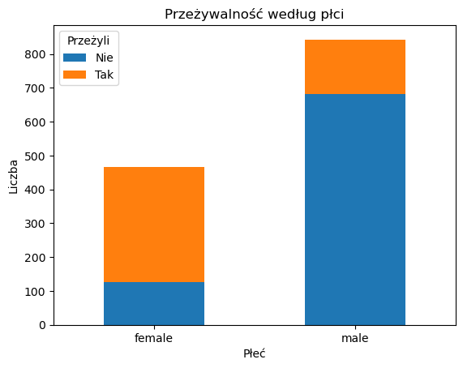

```python
df_clean = df.dropna(subset=['survived', 'sex'])
survived_sex_counts = df_clean.groupby(['sex', 'survived']).size().unstack()
survived_sex_counts.plot(kind='bar', stacked=True)
plt.title('Przeżywalność według płci')
plt.xlabel('Płeć')
plt.ylabel('Liczba')
plt.xticks(rotation=0)
plt.legend(title='Przeżyli', labels=['Nie', 'Tak'])
```

Na wykresie wyraźnie widać, że stosunkowo więcej kobiet niż mężczyzn uratowało się

Czyli można wyciągnąć wniosek, że brano pod uwagę to czy osoba ratowana była kobietą a także, że w takim wypadku należał jej się priorytet miejsca w szalupie.

## Prośba o pokazanie liczby pasażerów wg. podziału na płeć

```python
pwp = df['sex'].value_counts()
result = {
    "type": "dataframe",
    "value": pwp.to_frame(name='count')
}
pwp
```

```
sex
male      843
female    466
Name: count, dtype: int64
```

Tutaj wyraźnie widać, że mężczyzn na pokładzie było więcej niemal dwukrotnie od kobiet, co wzmacnia poziom relacji z wykresu powyżej, ponieważ mężczyzn zginęło więcej.

### Wniosek:

mężczyzna miał o wiele mniejsze szanse przetrwania niż kobieta

## Prośba o pokazanie wykresu punktowego uczestników rejsu według podziału na wiek

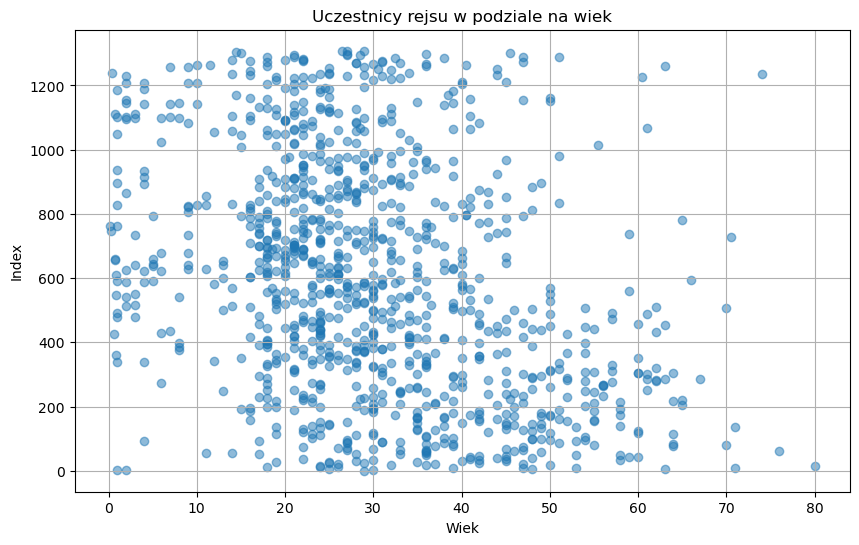

```python
plt.figure(figsize=(10, 6))
plt.scatter(df['age'], df.index, alpha=0.5)
plt.title('Uczestnicy rejsu w podziale na wiek')
plt.xlabel('Wiek')
plt.ylabel('Index')
plt.grid(True)
```

## A teraz pokażę ten sam wykres z oznaczeniem innym kolorem wszystkich pasażerów poniżej 18 roku życia.

[figure not shown]

```python
df = df.dropna(subset=['age'])
#Oddzielenie dorosłych od dzieci
children = df[df['age'] < 18]
adults = df[df['age'] >= 18]

# Zliczenie dorosłych i dzieci
num_children = len(children)
num_adults = len(adults)

# Stworzenie wykresu
plt.figure(figsize=(10, 6))
plt.scatter(children['age'], children.index, color='blue', label=f'Dzieci (<18): {num_children}')
plt.scatter(adults['age'], adults.index, color='red', label=f'Dorośli (>=18): {num_adults}')

# Dodanie nazw osi i legendy
plt.xlabel('Wiek')
plt.ylabel('Passenger Index')
plt.title('Wykres punktowy uczestników według podziału na płeć')
plt.legend()

# Reverse axes
plt.gca().invert_yaxis()
```

W kolumnie age w samej bazie danych mamy tylko 1046 elementów i ten wykres jest zrobiony tylko dla tej grupy, ale wyraźnie widać, na podstawie tak dużej grupy próbnej jak kształtował się podział wiekowy i jaki mniej więcej odsetek stanowiły dzieci.

Procentowo wyglądało to tak:

```
(np.float64(-1.202097982230382),
 np.float64(1.1048616765885606),
 np.float64(-1.0999999847206687),
 np.float64(1.0999998206482027))
```

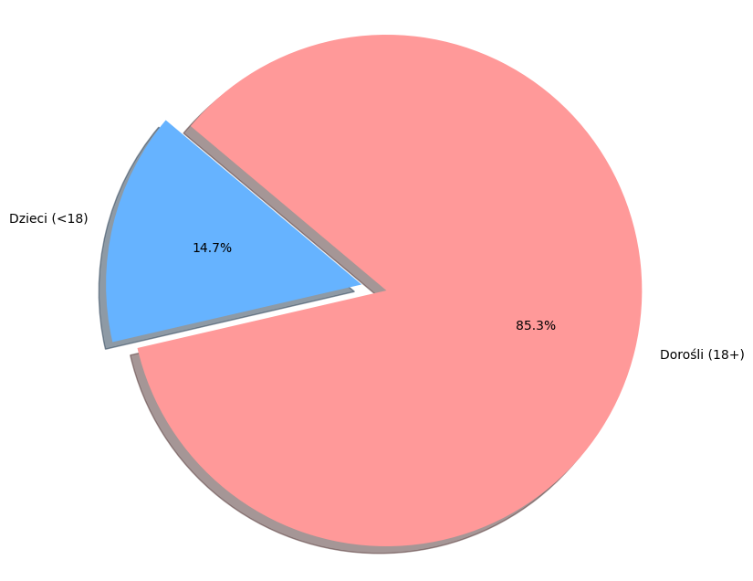

```python
# Przeliczenie dorosłych i dzieci
children_count = df[df['age'] < 18].shape[0]
adults_count = df[df['age'] >= 18].shape[0]

# Stworzenie wykresu kołowego
labels = ['Dzieci (<18)', 'Dorośli (18+)']
sizes = [children_count, adults_count]
colors = ['#66b3ff','#ff9999']
explode = (0.1, 0)  # wykrojenie kawałka

plt.figure(figsize=(8, 8))
plt.pie(sizes, explode=explode, labels=labels, colors=colors, autopct='%1.1f%%', shadow=True, startangle=140)
plt.axis('equal')
```

# A jak nazywały się najmłodsze osoby które przeżyły katastrofę?

```python
titanic_df = df
prz_df = titanic_df[titanic_df['survived'] == 1]
najm = prz_df.nsmallest(10, 'age')
result = {
    "type": "dataframe",
    "value": najm
}
najm
```

|  | pclass | survived | name | sex | age | sibsp | parch | ticket | fare | cabin | embarked | boat | body | home.dest |
| --- | --- | --- | --- | --- | --- | --- | --- | --- | --- | --- | --- | --- | --- | --- |
| 763 | 3.0 | 1.0 | Dean, Miss. Elizabeth Gladys "Millvina" | female | 0.1667 | 1.0 | 2.0 | C.A. 2315 | 20.5750 | NaN | S | 10 | NaN | Devon, England Wichita, KS |
| 1240 | 3.0 | 1.0 | Thomas, Master. Assad Alexander | male | 0.4167 | 0.0 | 1.0 | 2625 | 8.5167 | NaN | C | 16 | NaN | NaN |
| 427 | 2.0 | 1.0 | Hamalainen, Master. Viljo | male | 0.6667 | 1.0 | 1.0 | 250649 | 14.5000 | NaN | S | 4 | NaN | Detroit, MI |
| 657 | 3.0 | 1.0 | Baclini, Miss. Eugenie | female | 0.7500 | 2.0 | 1.0 | 2666 | 19.2583 | NaN | C | C | NaN | Syria New York, NY |
| 658 | 3.0 | 1.0 | Baclini, Miss. Helene Barbara | female | 0.7500 | 2.0 | 1.0 | 2666 | 19.2583 | NaN | C | C | NaN | Syria New York, NY |
| 359 | 2.0 | 1.0 | Caldwell, Master. Alden Gates | male | 0.8333 | 0.0 | 2.0 | 248738 | 29.0000 | NaN | S | 13 | NaN | Bangkok, Thailand / Roseville, IL |
| 548 | 2.0 | 1.0 | Richards, Master. George Sibley | male | 0.8333 | 1.0 | 1.0 | 29106 | 18.7500 | NaN | S | 4 | NaN | Cornwall / Akron, OH |
| 611 | 3.0 | 1.0 | Aks, Master. Philip Frank | male | 0.8333 | 0.0 | 1.0 | 392091 | 9.3500 | NaN | S | 11 | NaN | London, England Norfolk, VA |
| 1 | 1.0 | 1.0 | Allison, Master. Hudson Trevor | male | 0.9167 | 1.0 | 2.0 | 113781 | 151.5500 | C22 C26 | S | 11 | NaN | Montreal, PQ / Chesterville, ON |
| 590 | 2.0 | 1.0 | West, Miss. Barbara J | female | 0.9167 | 1.0 | 2.0 | C.A. 34651 | 27.7500 | NaN | S | 10 | NaN | Bournmouth, England |

Tych ludzi jeszcze całkiem niedawno można było spotkać na ulicy :)

## Pokazanie wykresu kołowego procentowego udziału pasażerów w poszczególnych klasach z uwzględnieniem płci.

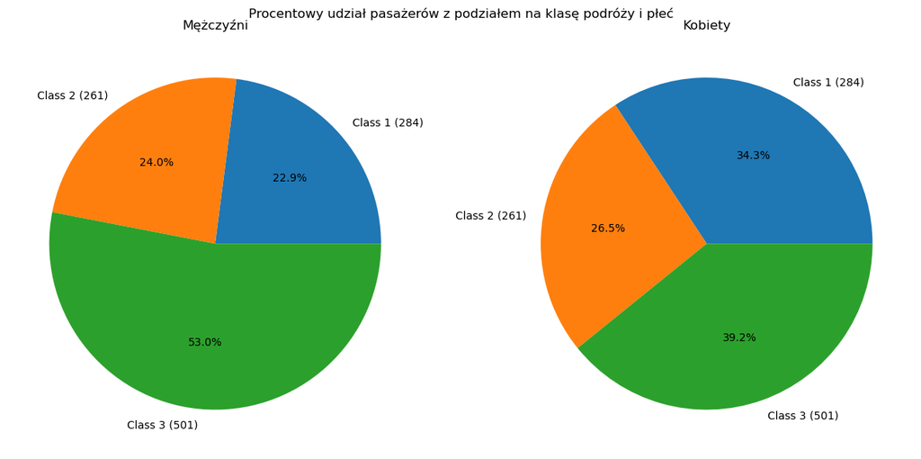

```python
df = df.dropna(subset=['pclass', 'sex'])

# Grupowanie po klasie i płci a potem zliczenie
class_sex_counts = df.groupby(['pclass', 'sex']).size().unstack()

# Przeliczenie całkowitej ilości pasażerów w każdej z klas
class_totals = df['pclass'].value_counts().sort_index()

# Stworzenie nazw labeli w wartości sumarycznej klas
labels = [f'Class {int(cls)} ({total})' for cls, total in class_totals.items()]

# Narysowanie wykresu z podziałem na płeć
fig, axes = plt.subplots(1, 2, figsize=(12, 6))
class_sex_counts.plot(kind='pie', y='male', labels=labels, autopct='%1.1f%%', ax=axes[0], legend=False)
class_sex_counts.plot(kind='pie', y='female', labels=labels, autopct='%1.1f%%', ax=axes[1], legend=False)

# Ustawienie tytułów
axes[0].set_title('Mężczyźni')
axes[1].set_title('Kobiety')
for ax in axes:
    ax.set_ylabel('')

plt.suptitle('Procentowy udział pasażerów z podziałem na klasę podróży i płeć')
plt.tight_layout()
```

# Należy zaznaczyć, że liczby zawarte w nawiasach oznaczają liczbę wszystkich biletów w danej klasie.

Wniosek jaki się nasuwa to to, że procentowo i liczebnie najwięcej kobiet oraz mężczyzn podróżowało w klasie 3

# Pokaż wykres kołowy śmiertelności do przeżycia dla *klasy 1* według podziału na wiek.

```
(np.float64(-1.099999739845874),
 np.float64(1.099999095319948),
 np.float64(-1.0999989640946295),
 np.float64(1.0999999506711728))
```

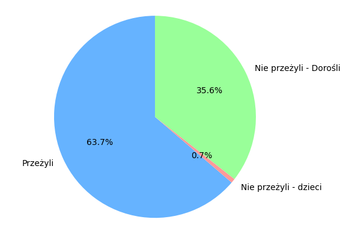

```python
# Odfiltrowanie klasy 1
class_1_df = df[df['pclass'] == 1.0]

# Podział na wiek
class_1_df['age_group'] = class_1_df['age'].apply(lambda x: 'child' if x < 18 else 'adult')

# Przeliczenie śmiertelności i przeżycia po grupie wiekowej
survived_counts = class_1_df[class_1_df['survived'] == 1].shape[0]
not_survived_children = class_1_df[(class_1_df['survived'] == 0) & (class_1_df['age_group'] == 'child')].shape[0]
not_survived_adults = class_1_df[(class_1_df['survived'] == 0) & (class_1_df['age_group'] == 'adult')].shape[0]

# Przygotowanie danych pod wykres kołowy
total_passengers = class_1_df.shape[0]
not_survived_total = not_survived_children + not_survived_adults
survived_total = total_passengers - not_survived_total

# Zrobienie wykresu
labels = ['Przeżyli', 'Nie przeżyli - dzieci', 'Nie przeżyli - Dorośli']
sizes = [survived_total, not_survived_children, not_survived_adults]
colors = ['#66b3ff', '#ff9999', '#99ff99']

fig, ax = plt.subplots()
ax.pie(sizes, labels=labels, colors=colors, autopct='%1.1f%%', startangle=90)
ax.axis('equal')
```

# Pokaż wykres kołowy śmiertelności do przeżycia dla *klasy 2* według podziału na wiek.

```
(np.float64(-1.0999930334354537),
 np.float64(1.0999991011840888),
 np.float64(-1.0999994078064712),
 np.float64(1.0999999718003082))
```

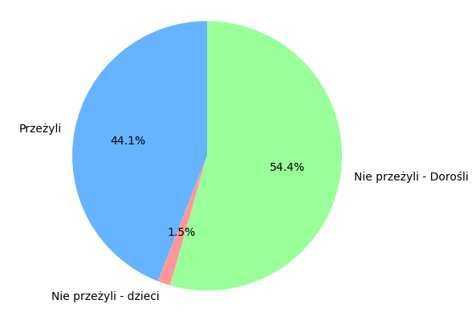

```python
# Odfiltrowanie klasy 2
class_2_df = df[df['pclass'] == 2.0]

# Podział na wiek
class_2_df['age_group'] = class_2_df['age'].apply(lambda x: 'child' if x < 18 else 'adult')

# Przeliczenie śmiertelności i przeżycia po grupie wiekowej
survived_counts = class_2_df[class_2_df['survived'] == 1].shape[0]
not_survived_children = class_2_df[(class_2_df['survived'] == 0) & (class_2_df['age_group'] == 'child')].shape[0]
not_survived_adults = class_2_df[(class_2_df['survived'] == 0) & (class_2_df['age_group'] == 'adult')].shape[0]

# Przygotowanie danych pod wykres kołowy
total_passengers = class_2_df.shape[0]
not_survived_total = not_survived_children + not_survived_adults
survived_total = total_passengers - not_survived_total

# Zrobienie wykresu
labels = ['Przeżyli', 'Nie przeżyli - dzieci', 'Nie przeżyli - Dorośli']
sizes = [survived_total, not_survived_children, not_survived_adults]
colors = ['#66b3ff', '#ff9999', '#99ff99']

fig, ax = plt.subplots()
ax.pie(sizes, labels=labels, colors=colors, autopct='%1.1f%%', startangle=90)
ax.axis('equal')
```

# Pokaż wykres kołowy śmiertelności do przeżycia dla *klasy 3* według podziału na wiek.

```
(np.float64(-1.0999998381915566),
 np.float64(1.0999991064053791),
 np.float64(-1.0999987116082428),
 np.float64(1.0999999386480115))
```

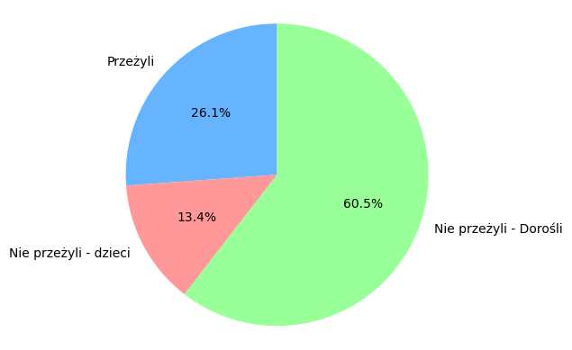

```python
# Odfiltrowanie klasy 3
class_3_df = df[df['pclass'] == 3.0]

# Podział na wiek
class_3_df['age_group'] = class_3_df['age'].apply(lambda x: 'child' if x < 18 else 'adult')

# Przeliczenie śmiertelności i przeżycia po grupie wiekowej
survived_counts = class_3_df[class_3_df['survived'] == 1].shape[0]
not_survived_children = class_3_df[(class_3_df['survived'] == 0) & (class_3_df['age_group'] == 'child')].shape[0]
not_survived_adults = class_3_df[(class_3_df['survived'] == 0) & (class_3_df['age_group'] == 'adult')].shape[0]

# Przygotowanie danych pod wykres kołowy
total_passengers = class_3_df.shape[0]
not_survived_total = not_survived_children + not_survived_adults
survived_total = total_passengers - not_survived_total

# Zrobienie wykresu
labels = ['Przeżyli', 'Nie przeżyli - dzieci', 'Nie przeżyli - Dorośli']
sizes = [survived_total, not_survived_children, not_survived_adults]
colors = ['#66b3ff', '#ff9999', '#99ff99']

fig, ax = plt.subplots()
ax.pie(sizes, labels=labels, colors=colors, autopct='%1.1f%%', startangle=90)
ax.axis('equal')
```

## WNIOSKI:

Niestety największa śmiertelnośc była w klasie 3 potem w klasie 2 a najmniejsza w klasie 1. Równolegle, dzieci miały największą szanse przeżycia w klasie 1.

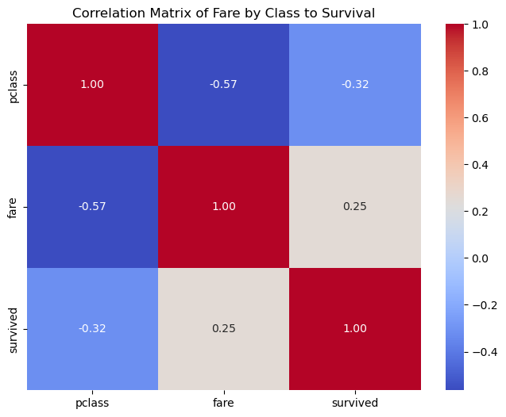

```python
# Przeliczenie macierzy
correlation_matrix = df[['pclass', 'fare', 'survived']].corr()

# Wyrysowanie macierzy
plt.figure(figsize=(8, 6))
sns.heatmap(correlation_matrix, annot=True, cmap='coolwarm', fmt=".2f")
plt.title('Correlation Matrix of Fare by Class to Survival')
```

Gdy rozbije się tę macierz na poszczególne klasy wtedy lepiej widać zależność ceny od śmiertelności jednak wykresy kołowe pokazują więcej.

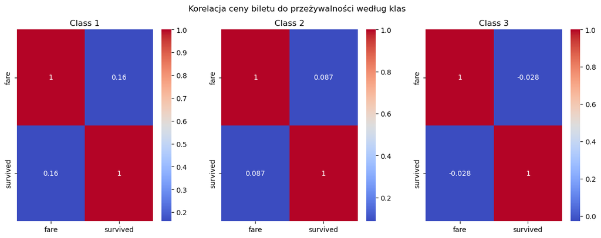

```python
# Filter out rows with missing values in 'fare', 'pclass', or 'survived'
df_filtered = df.dropna(subset=['fare', 'pclass', 'survived'])

# Create a correlation matrix for each class
correlation_matrices = {}
for pclass in df_filtered['pclass'].unique():
    class_data = df_filtered[df_filtered['pclass'] == pclass]
    correlation_matrix = class_data[['fare', 'survived']].corr()
    correlation_matrices[pclass] = correlation_matrix

# Plot the correlation matrices
fig, axes = plt.subplots(1, len(correlation_matrices), figsize=(15, 5))
fig.suptitle('Korelacja ceny biletu do przeżywalności według klas')

for ax, (pclass, corr_matrix) in zip(axes, correlation_matrices.items()):
    sns.heatmap(corr_matrix, annot=True, cmap='coolwarm', ax=ax)
    ax.set_title(f'Class {int(pclass)}')
```

## WNIOSKI:

- w klasie 1:

[output not shown]

- w klasie 2:

[output not shown]

- w klasie 3:

[output not shown]

# Wniosek jaki się sam nasuwa to taki, że wykres zależności ceny od przeżywalności jest nieadekwatny i żeby uzyskać bardziej wiarygodne dane należy posłużyć sie wykresem kołowym osobnym dla każdej z klas. Wtedy na własne oczy możemy ujrzeć jak w rzeczywistości wyglądała sytuacja i gdzie była największa śmiertelność.